# Hands-On Example: Creating a Final Report with Quarto

Author

Joshua J. Cook

Published

October 21, 2024

## Objective

The goal of this section is to use the complete CDISC-compliant SDTM and ADaM datasets to **create a final report using Quarto**. This report will include tables, listings, and figures (TLFs), which are commonly required for regulatory submissions.

## Key Points for Presentation

- **Overview**: Use the complete CDISC-compliant SDTM and ADaM datasets to create a final report using Quarto.
- **Required Libraries**: `{tidyverse}` for data manipulation and figures, `{gt}` and `{gtsummary}` for listings and tables, and `{quarto}` for generating the final reproducible report.
- **Input Data**: Imputed SDTM and ADaM Datasets.
- **Data Understanding**: Understand how to create TLFs using imputed datasets to ensure compliance with regulatory standards.
- **Report Creation Process**:
  - Generate tables and listings using `{gt}` and `{gtsummary}`.
  - Create figures using `{ggplot2}`.
  - Compile the final report using `{quarto}`.

## Step-by-Step Report Creation with Quarto

### Step 1: Load Required Libraries

```r
if (!requireNamespace(c("tidyverse", "gt", "gtsummary", "quarto"), quietly = TRUE)) {
  install.packages(c("tidyverse", "gt", "gtsummary", "quarto"))
}

# Load necessary libraries
library(tidyverse)  # Tidyverse for data manipulation and figures
library(gt)         # GT for creating high-quality tables
library(gtsummary)  # Gtsummary for creating clinical trial summary tables
library(quarto)     # Quarto for generating the final report

# Loading the dataset in the final document
sdtm_dm_imputed <- readRDS("sdtm_dm_imputed.rds") # Loads our SDTM data
adam_dm_imputed <- readRDS("adam_dm_imputed.rds") # Loads our ADaM data
```

**Explanation**: We start by loading the `{tidyverse}` package for data manipulation and visualization, `{gt}` and `{gtsummary}` for creating tables and listings, and `{quarto}` for generating the final report. We also load in our previously generated SDTM and ADaM datasets.

### Step 2: Generate Summary Tables

```r
# Generate a summary table for demographic characteristics using gtsummary
summary_table <- sdtm_dm_imputed %>%
  # Select relevant columns for summarization: AGE, SEX, ETHNIC, and RACE
  select(AGE, SEX, ETHNIC, RACE) %>%

  # Create a summary table with grouping by SEX
  tbl_summary(
    by = SEX,  # Group data by SEX to summarize separately for each group
    statistic = list(all_continuous() ~ "{mean} ({sd})")  # Define how to summarize continuous variables (mean and standard deviation)
  ) %>%

  # Bold the labels for better visualization in the output table
  bold_labels()
```

```
12 observations missing `SEX` have been removed. To include these observations, use `forcats::fct_na_value_to_level()` on `SEX` column before passing to `tbl_summary()`.
```

```r
# View the summary table
summary_table
```

| **Characteristic** | **F**, N = 61<sup>1</sup> | **M**, N = 77<sup>1</sup> |
| --- | --- | --- |
| AGE | 49 (15) | 46 (17) |
| ETHNIC |  |  |
| HISPANIC OR LATINO | 14 (23%) | 30 (39%) |
| NOT HISPANIC OR LATINO | 29 (48%) | 5 (6.5%) |
| NOT REPORTED | 6 (9.8%) | 21 (27%) |
| UNKNOWN | 12 (20%) | 21 (27%) |
| RACE |  |  |
| AMERICAN INDIAN OR ALASKA NATIVE | 7 (11%) | 0 (0%) |
| ASIAN | 7 (11%) | 0 (0%) |
| BLACK OR AFRICAN AMERICAN | 0 (0%) | 15 (19%) |
| NATIVE HAWAIIAN OR OTHER PACIFIC ISLANDER | 7 (11%) | 0 (0%) |
| NOT REPORTED | 8 (13%) | 26 (34%) |
| OTHER | 8 (13%) | 14 (18%) |
| UNKNOWN | 19 (31%) | 7 (9.1%) |
| WHITE | 5 (8.2%) | 15 (19%) |

<sup>1</sup> Mean (SD); n (%)

**Explanation**: Here, we use `{gtsummary}` to create a summary table for demographic characteristics, grouped by `SEX`. The `tbl_summary()` function is used to summarize the `AGE`, `ETHNIC`, and `RACE` variables, with continuous variables reported as mean and standard deviation.

### Step 3: Generate High-Quality Tables for Listings

```r
# Generate a high-quality listing using gt
listing_table <- sdtm_dm_imputed %>%
  select(STUDYID, USUBJID, AGE, SEX, ETHNIC, RACE) %>%  # Select relevant columns for listing
  gt()  # Create a high-quality table using gt

# View the listing table
listing_table
```

| STUDYID | USUBJID | AGE | SEX | ETHNIC | RACE |
| --- | --- | --- | --- | --- | --- |
| CDASH_DEMO_01 | CDASH_DEMO_01-SUB001 | 53 | F | NOT HISPANIC OR LATINO | NOT REPORTED |
| CDASH_DEMO_01 | CDASH_DEMO_01-SUB002 | 60 | F | HISPANIC OR LATINO | NATIVE HAWAIIAN OR OTHER PACIFIC ISLANDER |
| CDASH_DEMO_01 | CDASH_DEMO_01-SUB003 | 32 | F | NOT HISPANIC OR LATINO | UNKNOWN |
| CDASH_DEMO_01 | CDASH_DEMO_01-SUB004 | 49 | F | UNKNOWN | AMERICAN INDIAN OR ALASKA NATIVE |
| CDASH_DEMO_01 | CDASH_DEMO_01-SUB005 | 24 | M | HISPANIC OR LATINO | NOT REPORTED |
| CDASH_DEMO_01 | CDASH_DEMO_01-SUB006 | 24 | M | HISPANIC OR LATINO | NOT REPORTED |
| CDASH_DEMO_01 | CDASH_DEMO_01-SUB007 | 58 | F | NOT HISPANIC OR LATINO | OTHER |
| CDASH_DEMO_01 | CDASH_DEMO_01-SUB008 | 40 | M | NOT REPORTED | BLACK OR AFRICAN AMERICAN |
| CDASH_DEMO_01 | CDASH_DEMO_01-SUB009 | 44 | M | NOT REPORTED | NOT REPORTED |
| CDASH_DEMO_01 | CDASH_DEMO_01-SUB010 | 77 | M | HISPANIC OR LATINO | WHITE |
| CDASH_DEMO_01 | CDASH_DEMO_01-SUB011 | 70 | M | UNKNOWN | OTHER |
| CDASH_DEMO_01 | CDASH_DEMO_01-SUB012 | 24 | F | NOT HISPANIC OR LATINO | UNKNOWN |
| CDASH_DEMO_01 | CDASH_DEMO_01-SUB013 | 70 | M | HISPANIC OR LATINO | BLACK OR AFRICAN AMERICAN |
| CDASH_DEMO_01 | CDASH_DEMO_01-SUB014 | 44 | M | UNKNOWN | UNKNOWN |
| CDASH_DEMO_01 | CDASH_DEMO_01-SUB015 | 53 | M | NOT HISPANIC OR LATINO | NOT REPORTED |
| CDASH_DEMO_01 | CDASH_DEMO_01-SUB016 | 51 | F | HISPANIC OR LATINO | ASIAN |
| CDASH_DEMO_01 | CDASH_DEMO_01-SUB017 | 80 | F | NOT REPORTED | UNKNOWN |
| CDASH_DEMO_01 | CDASH_DEMO_01-SUB018 | 24 | M | NOT REPORTED | WHITE |
| CDASH_DEMO_01 | CDASH_DEMO_01-SUB019 | 42 | F | UNKNOWN | WHITE |
| CDASH_DEMO_01 | CDASH_DEMO_01-SUB020 | 55 | M | UNKNOWN | OTHER |
| CDASH_DEMO_01 | CDASH_DEMO_01-SUB001 | 53 | F | NOT HISPANIC OR LATINO | NOT REPORTED |
| CDASH_DEMO_01 | CDASH_DEMO_01-SUB002 | 60 | F | HISPANIC OR LATINO | NATIVE HAWAIIAN OR OTHER PACIFIC ISLANDER |
| CDASH_DEMO_01 | CDASH_DEMO_01-SUB003 | 32 | F | NOT HISPANIC OR LATINO | UNKNOWN |
| CDASH_DEMO_01 | CDASH_DEMO_01-SUB004 | 49 | F | UNKNOWN | AMERICAN INDIAN OR ALASKA NATIVE |
| CDASH_DEMO_01 | CDASH_DEMO_01-SUB005 | 24 | M | HISPANIC OR LATINO | NOT REPORTED |
| CDASH_DEMO_01 | CDASH_DEMO_01-SUB006 | 26 | M | HISPANIC OR LATINO | NOT REPORTED |
| CDASH_DEMO_01 | CDASH_DEMO_01-SUB007 | 58 | F | NOT HISPANIC OR LATINO | OTHER |
| CDASH_DEMO_01 | CDASH_DEMO_01-SUB008 | 40 | M | NOT REPORTED | BLACK OR AFRICAN AMERICAN |
| CDASH_DEMO_01 | CDASH_DEMO_01-SUB009 | 44 | M | NOT REPORTED | NOT REPORTED |
| CDASH_DEMO_01 | CDASH_DEMO_01-SUB010 | 53 | M | HISPANIC OR LATINO | WHITE |

[output cut: 120 more lines]

**Explanation**: In this step, we use `{gt}` to create a listing of the demographic data. The `gt()` function helps generate publication-quality tables that can be included in the final report.

### Step 4: Create Figures Using ggplot2

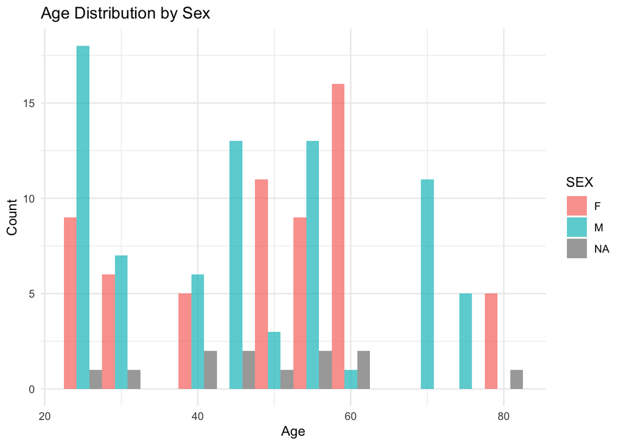

```r
# Generate a histogram of AGE by SEX
age_histogram <- sdtm_dm_imputed %>%
  # Use the pipe operator to feed data into ggplot function for visualization
  ggplot(aes(x = AGE, fill = SEX)) +

  # Create a histogram with 'geom_histogram()'
  # 'aes()' defines the variables for the x-axis and fill color (by SEX)
  geom_histogram(binwidth = 5, alpha = 0.7, position = "dodge") +

  # Add descriptive labels for the title, x-axis, and y-axis of the plot
  labs(title = "Age Distribution by Sex", x = "Age", y = "Count") +

  # Apply 'theme_minimal()' for a cleaner, minimal visual style
  theme_minimal()

# View the histogram
age_histogram
```

**Explanation**: We use `{ggplot2}` from `{tidyverse}` to create a histogram of `AGE` by `SEX`. This figure helps visualize the distribution of age across different sexes in the dataset.

## Important CDISC Concepts for Creating Regulatory-Compliant Reports

- **Standardization**: The use of CDISC standards ensures that datasets are consistent across different clinical trials, which is essential for regulatory review.
- **Traceability**: All derived variables, tables, and figures must be traceable to their source data, ensuring transparency.
- **Metadata Documentation**: Proper documentation of variables and methods used in TLF generation is crucial for regulatory submissions.
- **Regulatory Requirements**: TLFs are a key part of clinical trial reporting, and adhering to ADaM standards ensures that these outputs meet regulatory guidelines.

## Summary of Report Creation

- **Tables and Listings**: Created summary tables and listings using `{gt}` and `{gtsummary}` to meet regulatory submission requirements.
- **Figures**: Visualized key demographic data using `{ggplot2}`.
- **Quarto Report**: Compiled all tables, listings, and figures into a final report using `{quarto}`.
- **Compliance with CDISC Standards**: Ensured that all outputs were compliant with CDISC standards, providing traceability and proper documentation.

This hands-on section helps participants understand how to create a final clinical trial report that includes TLFs, emphasizing compliance with CDISC standards for regulatory submissions.